# PEEP II Acoustics Data Gathering

Rick O. Gilmore

2019-08-01 12:14:44

# 1 Background/Purpose

This notebook describes how to gather the PEEP-II acoustics data, including the formats of data files and fields.

# 2 Set-up

```r
knitr::opts_chunk$set(echo = TRUE)

pkg_list <- c("tidyverse", "ggplot2", "R.matlab")
lapply(pkg_list, library, quietly = TRUE, character.only = TRUE)
```

[output not shown]

# 3 Gather

## 3.1 Explore and document directory structure

The PEEP II acoustics data are stored in `~/Box Sync/b-peep-project Shared/PEEP2 acoustics/`.

```r
acoustics_dir <- "~/Box Sync/b-peep-project Shared/PEEP2 acoustics/"
dir(acoustics_dir)
```

```
 [1] "001"
 [2] "002"
 [3] "003"
 [4] "005"
 [5] "006"
 [6] "007"
 [7] "008"
 [8] "009"
 [9] "011"
[10] "012"
[11] "013"
[12] "014"
[13] "015"
[14] "015_original"
[15] "017"
```

[output cut: 56 more lines]

There are separate directories for the individual participants, e.g. `001`.

Peter Moriarity recalls that `015_original` might have been recorded at 96,000 Hz (48,000 Hz was the standard for the rest). This participant may also have required down-sampling/editing to fit within the 10 s/utterance limit.

The contents of the `001` directory is as follows.

```r
dir(paste0(acoustics_dir, "/001"))
```

```
[1] "001_SCRIPT_ORDER.mat" "data"                 "new_utterance_times"
[4] "norm_96000"           "norm_mono_unfiltered" "plots"
[7] "raw"                  "rmsnorm"              "utterance_times"
```

I presume that we’ll want the `rmsnorm` data, but will check on that with Peter Moriarty.

```r
dir(paste0(acoustics_dir, "/001/rmsnorm"))
```

```
 [1] "001-ang-chk-a.wav" "001-ang-chk-b.wav" "001-ang-din-a.wav"
 [4] "001-ang-din-b.wav" "001-ang-hlp-a.wav" "001-ang-hlp-b.wav"
 [7] "001-ang-tlk-a.wav" "001-ang-tlk-b.wav" "001-hap-chk-a.wav"
[10] "001-hap-chk-b.wav" "001-hap-din-a.wav" "001-hap-din-b.wav"
[13] "001-hap-hlp-a.wav" "001-hap-hlp-b.wav" "001-hap-tlk-a.wav"
[16] "001-hap-tlk-b.wav" "001-neu-chk-a.wav" "001-neu-chk-b.wav"
[19] "001-neu-din-a.wav" "001-neu-din-b.wav" "001-neu-hlp-a.wav"
[22] "001-neu-hlp-b.wav" "001-neu-tlk-a.wav" "001-neu-tlk-b.wav"
[25] "001-sad-chk-a.wav" "001-sad-chk-b.wav" "001-sad-din-a.wav"
[28] "001-sad-din-b.wav" "001-sad-hlp-a.wav" "001-sad-hlp-b.wav"
[31] "001-sad-tlk-a.wav" "001-sad-tlk-b.wav"
```

These look like the normed audio files. Investigating the `data` subfolder, I find the acoustic ratings.

```r
dir(paste0(acoustics_dir, "/001/data"))
```

```
[1] "Duration"     "F0"           "Formants"     "HNR"
[5] "Intensity"    "LTAS"         "VoiceQuality"
```

Examining the `F0` directory shows the following:

```r
dir(paste0(acoustics_dir, "/001/data/F0"))
```

```
[1] "F0"
```

Drilling down into the F0 directory, we see the following:

```r
list.files(paste0(acoustics_dir, "/001/data/F0/F0/mean"))
```

```
[1] "F0.mat"
```

## 3.2 Open `F0.mat` file

There is a MATLAB file `F0.mat` with the raw data. To attempt to read it, I installed the `R.matlab` package via `install.packages("R.matlab")`.

```r
f0_001 <- R.matlab::readMat(paste0(acoustics_dir, "/001/data/F0/F0/mean/F0.mat"))
f0_001
```

```
$data
, , 1

         [,1]     [,2]     [,3]     [,4]
[1,] 208.1734 376.2629 189.8569 243.3438
[2,] 199.5333 310.4244 196.8328 261.5359
[3,] 161.7319 294.7491 200.0279 183.3066
[4,] 211.3701 260.7541 214.3857 173.1763
[5,] 155.6825 260.0319 174.2912 244.0735
[6,] 219.0432 289.9678 211.8268 253.8244
[7,] 174.0038 281.2974 195.2584 217.4076
[8,] 155.8628 246.8765 159.2683 181.3905

, , 2

         [,1]     [,2]     [,3]     [,4]
[1,] 215.4559 287.2466 198.1366 189.1993
[2,] 181.3155 321.3840 171.8007 221.8283
[3,] 230.3837 292.1370 179.4012 184.3978
[4,] 189.9672 283.7442 156.8966 119.4965
[5,] 141.3094 255.5748 153.2068 204.5958
[6,] 180.9676 273.0528 154.4360 297.8561
[7,] 160.8478 294.0105 185.2666 171.5249
[8,] 152.7723 211.8513 147.5627 151.8017

, , 3

         [,1]     [,2]     [,3]     [,4]
[1,] 195.9910 314.0293 146.9547 154.2104
[2,] 213.2310 341.0305 236.1695 237.2501
[3,] 196.3294 236.3251 156.3054 159.1751
[4,] 249.1237 314.1359 147.9066 134.1428
[5,] 159.0897 318.9745 149.8470 237.7615
[6,] 221.5013 231.7808 193.2992 203.2320
[7,] 165.8317 304.6992 239.8949 323.9173
[8,] 170.3585 270.5690 150.2848 163.5100

, , 4

         [,1]     [,2]     [,3]     [,4]
[1,] 253.0072 315.4946 154.5985 150.4273
[2,] 153.9817 338.0740 216.7660 157.8141
[3,] 165.9760 301.4651 168.6320 228.8204
[4,] 223.5631 269.4769 185.6222 201.2364
[5,] 169.3601 246.4594 158.9510 213.0037
[6,] 157.8387 309.6688 173.0259 204.0181
[7,] 138.5787 200.3521 209.4985 179.6759
[8,] 146.2894 312.7811 142.6855 152.2703


attr(,"header")
attr(,"header")$description
[1] "MATLAB 5.0 MAT-file, Platform: MACI64, Created on: Wed May 17 00:03:55 2017                                         "

attr(,"header")$version
[1] "5"

attr(,"header")$endian
[1] "little"
```

Use the `str()` function to summarize the details.

```r
str(f0_001)
```

```
List of 1
 $ data: num [1:8, 1:4, 1:4] 208 200 162 211 156 ...
 - attr(*, "header")=List of 3
  ..$ description: chr "MATLAB 5.0 MAT-file, Platform: MACI64, Created on: Wed May 17 00:03:55 2017                                         "
  ..$ version    : chr "5"
  ..$ endian     : chr "little"
```

This is an 8x4x4 array. The dimensions are as follows: 8 scripts {chk-a, chk-b, din-a, din-b, hlp-a, hlp-b, tlk-a, tlk-b} x 4 emotions {ang, hap, neu, sad}, x 4 utterances/script.

For now, let’s open one of the other acoustics data files.

```r
dir(paste0(acoustics_dir, "/001/data"))
```

```
[1] "Duration"     "F0"           "Formants"     "HNR"
[5] "Intensity"    "LTAS"         "VoiceQuality"
```

Let’s try the harmonic to noise ratio or HNR.

## 3.3 Opening HNR files

```r
dir(paste0(acoustics_dir, "/001/data/HNR"))
```

```
[1] "HNR"
```

```r
dir(paste0(acoustics_dir, "/001/data/HNR/HNR"))
```

```
[1] "CONTOURS" "MEAN"
```

Let’s examine `MEAN`.

```r
dir(paste0(acoustics_dir, "/001/data/HNR/HNR/MEAN"))
```

```
[1] "HNR.mat"
```

This is a `.mat` file we can open.

```r
HNR_mean_001 <- R.matlab::readMat(paste0(acoustics_dir, "/001/data/HNR/HNR/MEAN/HNR.mat"))
HNR_mean_001
```

```
$data
, , 1

          [,1]      [,2]       [,3]       [,4]
[1,] -45.66222 -30.52169 -17.792908 -13.421552
[2,] -15.60099 -30.03104 -17.229620  -7.805448
[3,] -37.43528 -10.15045 -32.658755 -42.451500
[4,] -27.95618 -15.76133  -6.847295  -1.426243
[5,] -61.96689 -12.67225 -22.432287  -8.605141
[6,] -41.93238 -41.31948 -15.373150 -10.094770
[7,] -24.66905 -16.15224  -3.505422   0.219002
[8,] -21.15949 -37.74559 -17.581397  -7.790659

, , 2

           [,1]       [,2]       [,3]        [,4]
[1,] -38.513936 -22.093879  -8.828156 -15.1193915
[2,] -12.953600  -8.358480  -8.287996  -4.3739534
[3,]  -3.602749 -21.290465 -10.941710   0.1856702
[4,] -39.169867 -21.667637  -6.969823 -10.1569377
[5,] -25.659208 -12.445412 -14.199316  -3.4152309
[6,] -14.170052  -9.234554 -25.896621  -3.3449712
[7,] -15.652920  -6.211338  -9.246410  -8.4387618
[8,] -15.231831 -10.366075  -8.235395  -6.6832473

, , 3

           [,1]       [,2]       [,3]       [,4]
[1,] -28.679774 -16.558253 -13.644357  -8.180088
[2,]  -9.637239  -4.480827 -13.550679  -7.455596
[3,] -13.275123 -11.893143  -6.091987  -2.021020
[4,] -39.841454 -15.132346 -11.151104 -13.621389
[5,] -46.285968  -7.484791 -15.236363 -17.948043
[6,] -13.399924 -19.259725  -9.696091  -2.990020
[7,] -31.931418 -27.494692 -15.097512 -19.843435
[8,] -37.510173 -37.783898 -36.550280 -32.637317

, , 4

           [,1]       [,2]       [,3]      [,4]
[1,] -11.856706 -26.189699 -15.896404 -33.14174
[2,] -44.718133 -18.058831 -12.800391 -17.20847
[3,] -22.411425 -28.777009 -20.403040 -26.85808
[4,] -12.239629  -6.725799 -16.369883 -13.72273
[5,] -20.194640 -10.889265  -9.007417 -13.08581
[6,] -14.265021  -7.038113 -11.999951  -1.32101
[7,]  -9.549505  -8.376751 -12.541299 -10.21312
[8,] -48.584031 -18.446382 -17.367195 -49.12618


attr(,"header")
attr(,"header")$description
[1] "MATLAB 5.0 MAT-file, Platform: MACI64, Created on: Wed May 17 00:06:56 2017                                         "

attr(,"header")$version
[1] "5"

attr(,"header")$endian
[1] "little"
```

```r
str(HNR_mean_001)
```

```
List of 1
 $ data: num [1:8, 1:4, 1:4] -45.7 -15.6 -37.4 -28 -62 ...
 - attr(*, "header")=List of 3
  ..$ description: chr "MATLAB 5.0 MAT-file, Platform: MACI64, Created on: Wed May 17 00:06:56 2017                                         "
  ..$ version    : chr "5"
  ..$ endian     : chr "little"
```

This also has an 8x4x4 array structure.

# 4 Steps toward a reproducible import scheme

## 4.1 Exploring how to flatten these arrays

Let’s create a test array with the same dimensionality, but named, so that we can explore how to properly flatten it.

```r
acoustics_test <- array(data = 1:(8*4*4), dim = c(8,4,4))
scr <- rep(rep(c("chk-a", "chk-b", "din-a", "din-b", "hlp-a", "hlp-b", "tlk-a", "tlk-b"), times = 4), times = 4)
emo <- rep(rep(c("ang", "hap", "neu", "sad"), each = 8), times = 4)
utt <- rep(1:4, each = 32)
df <- as.data.frame(acoustics_test)
df
```

| V1 | V2 | V3 | V4 | V5 | V6 | V7 | V8 | V9 | V10 | V11 | V12 | V13 | V14 | V15 | V16 |
| --- | --- | --- | --- | --- | --- | --- | --- | --- | --- | --- | --- | --- | --- | --- | --- |
| 1 | 9 | 17 | 25 | 33 | 41 | 49 | 57 | 65 | 73 | 81 | 89 | 97 | 105 | 113 | 121 |
| 2 | 10 | 18 | 26 | 34 | 42 | 50 | 58 | 66 | 74 | 82 | 90 | 98 | 106 | 114 | 122 |
| 3 | 11 | 19 | 27 | 35 | 43 | 51 | 59 | 67 | 75 | 83 | 91 | 99 | 107 | 115 | 123 |
| 4 | 12 | 20 | 28 | 36 | 44 | 52 | 60 | 68 | 76 | 84 | 92 | 100 | 108 | 116 | 124 |
| 5 | 13 | 21 | 29 | 37 | 45 | 53 | 61 | 69 | 77 | 85 | 93 | 101 | 109 | 117 | 125 |
| 6 | 14 | 22 | 30 | 38 | 46 | 54 | 62 | 70 | 78 | 86 | 94 | 102 | 110 | 118 | 126 |
| 7 | 15 | 23 | 31 | 39 | 47 | 55 | 63 | 71 | 79 | 87 | 95 | 103 | 111 | 119 | 127 |
| 8 | 16 | 24 | 32 | 40 | 48 | 56 | 64 | 72 | 80 | 88 | 96 | 104 | 112 | 120 | 128 |

So, I need to create one variable from the columns `V1` to `V16`.

```r
v <- NULL
for (i in 1:16) {
  v <- c(v, df[,i])
}
v
```

```
  [1]   1   2   3   4   5   6   7   8   9  10  11  12  13  14  15  16  17
 [18]  18  19  20  21  22  23  24  25  26  27  28  29  30  31  32  33  34
 [35]  35  36  37  38  39  40  41  42  43  44  45  46  47  48  49  50  51
 [52]  52  53  54  55  56  57  58  59  60  61  62  63  64  65  66  67  68
 [69]  69  70  71  72  73  74  75  76  77  78  79  80  81  82  83  84  85
 [86]  86  87  88  89  90  91  92  93  94  95  96  97  98  99 100 101 102
[103] 103 104 105 106 107 108 109 110 111 112 113 114 115 116 117 118 119
[120] 120 121 122 123 124 125 126 127 128
```

Now, I put the pieces together to form a data frame.

```r
acoustics_df <- data.frame(measure = v, script = scr, prosody = emo, utterance = utt)
```

## 4.2 Making an import function

A function that should work on the `F0` (mean) and `HNR` files is as follows:

```r
extract_acoustics_dat <- function(fn) {
  ac_mat <- R.matlab::readMat(fn)

  # Check dimensionality
  # if ((!dim(ac_mat)[1] == 8) |
  #   (!dim(ac_mat)[2] == 4) |
  #   (!dim(ac_mat)[3] == 4)) {
  #   stop("File is not 8x4x4 in dimension")
  # }

  # Convert to data frame
  ac_dat <- as.data.frame(ac_mat$data)

  # Convert data to 1D array
  v <- NULL
  for (i in 1:16) {
    v <- c(v, ac_dat[,i])
  }

  # Define values for nominal variables
  scr <- rep(rep(c("chk-a", "chk-b", "din-a", "din-b",
                   "hlp-a", "hlp-b", "tlk-a", "tlk-b"), times = 4), times = 4)
  emo <- rep(rep(c("ang", "hap", "neu", "sad"), each = 8), times = 4)
  utt <- rep(1:4, each = 32)

  # Assemble data frame and return
  data.frame(data.frame(measure = v, script = scr,
                        prosody = emo, utterance = utt))

}
```

Test the function.

```r
extract_acoustics_dat(fn = paste0(acoustics_dir, "/001/data/F0/F0/mean/F0.mat"))
```

| measure | script | prosody | utterance |
| --- | --- | --- | --- |
| 208.1734 | chk-a | ang | 1 |
| 199.5333 | chk-b | ang | 1 |
| 161.7319 | din-a | ang | 1 |
| 211.3701 | din-b | ang | 1 |
| 155.6825 | hlp-a | ang | 1 |
| 219.0432 | hlp-b | ang | 1 |
| 174.0038 | tlk-a | ang | 1 |
| 155.8628 | tlk-b | ang | 1 |
| 376.2629 | chk-a | hap | 1 |
| 310.4244 | chk-b | hap | 1 |

[output cut: 118 more lines]

It makes more sense to sort by utterance within script.

```r
d <- extract_acoustics_dat(fn = paste0(acoustics_dir, "/001/data/F0/F0/mean/F0.mat"))
d %>% dplyr::arrange(script, prosody, utterance)
```

| measure | script | prosody | utterance |
| --- | --- | --- | --- |
| 208.1734 | chk-a | ang | 1 |
| 215.4559 | chk-a | ang | 2 |
| 195.9910 | chk-a | ang | 3 |
| 253.0072 | chk-a | ang | 4 |
| 376.2629 | chk-a | hap | 1 |
| 287.2466 | chk-a | hap | 2 |
| 314.0293 | chk-a | hap | 3 |
| 315.4946 | chk-a | hap | 4 |
| 189.8569 | chk-a | neu | 1 |
| 198.1366 | chk-a | neu | 2 |

[output cut: 118 more lines]

Let’s incorporate this into the function.

```r
extract_matlab_acoustics_dat <- function(fn) {
  ac_mat <- R.matlab::readMat(fn)

  # Check dimensionality
  # if ((!dim(ac_mat)[1] == 8) |
  #   (!dim(ac_mat)[2] == 4) |
  #   (!dim(ac_mat)[3] == 4)) {
  #   stop("File is not 8x4x4 in dimension")
  # }

  # Convert to data frame
  ac_dat <- as.data.frame(ac_mat$data)

  # Convert data to 1D array
  v <- NULL
  for (i in 1:16) {
    v <- c(v, ac_dat[,i])
  }

  # Define values for nominal variables
  scr <- rep(rep(c("chk-a", "chk-b", "din-a", "din-b",
                   "hlp-a", "hlp-b", "tlk-a", "tlk-b"), times = 4), times = 4)
  emo <- rep(rep(c("ang", "hap", "neu", "sad"), each = 8), times = 4)
  utt <- rep(1:4, each = 32)

  # Assemble data frame and return
  df <- data.frame(data.frame(measure = v, script = scr,
                        prosody = emo, utterance = utt))
  dplyr::arrange(df, script, prosody, utterance)
}

extract_matlab_acoustics_dat(fn = paste0(acoustics_dir, "/001/data/F0/F0/mean/F0.mat"))
```

| measure | script | prosody | utterance |
| --- | --- | --- | --- |
| 208.1734 | chk-a | ang | 1 |
| 215.4559 | chk-a | ang | 2 |
| 195.9910 | chk-a | ang | 3 |
| 253.0072 | chk-a | ang | 4 |
| 376.2629 | chk-a | hap | 1 |
| 287.2466 | chk-a | hap | 2 |
| 314.0293 | chk-a | hap | 3 |
| 315.4946 | chk-a | hap | 4 |
| 189.8569 | chk-a | neu | 1 |
| 198.1366 | chk-a | neu | 2 |

[output cut: 118 more lines]

That looks good. An improvement would be to provide the measure name.

```r
extract_matlab_acoustics_dat_2 <- function(fn, measure_nm = "measure") {
  ac_mat <- R.matlab::readMat(fn)

  # Check dimensionality
  # if ((!dim(ac_mat)[1] == 8) |
  #   (!dim(ac_mat)[2] == 4) |
  #   (!dim(ac_mat)[3] == 4)) {
  #   stop("File is not 8x4x4 in dimension")
  # }

  # Convert to data frame
  ac_dat <- as.data.frame(ac_mat$data)

  # Convert data to 1D array
  v <- NULL
  for (i in 1:16) {
    v <- c(v, ac_dat[,i])
  }

  # Define values for nominal variables
  scr <- rep(rep(c("chk-a", "chk-b", "din-a", "din-b",
                   "hlp-a", "hlp-b", "tlk-a", "tlk-b"), times = 4), times = 4)
  emo <- rep(rep(c("ang", "hap", "neu", "sad"), each = 8), times = 4)
  utt <- rep(1:4, each = 32)

  # Assemble data frame and return
  df <- data.frame(data.frame(measure = v, script = scr,
                        prosody = emo, utterance = utt))
  # Rename measure (hacky)
  df[measure_nm] <- df$measure
  df <- dplyr::select(df, -measure)

  dplyr::arrange(df, script, prosody, utterance)
}

extract_matlab_acoustics_dat_2(fn = paste0(acoustics_dir, "/001/data/F0/F0/mean/F0.mat"), "F0_mean")
```

| script | prosody | utterance | F0_mean |
| --- | --- | --- | --- |
| chk-a | ang | 1 | 208.1734 |
| chk-a | ang | 2 | 215.4559 |
| chk-a | ang | 3 | 195.9910 |
| chk-a | ang | 4 | 253.0072 |
| chk-a | hap | 1 | 376.2629 |
| chk-a | hap | 2 | 287.2466 |
| chk-a | hap | 3 | 314.0293 |
| chk-a | hap | 4 | 315.4946 |
| chk-a | neu | 1 | 189.8569 |
| chk-a | neu | 2 | 198.1366 |

[output cut: 118 more lines]

```r
NA
```

This all works, except for the dimension checking. I will put this into an R file (`R/gather_clean_acoustics.R`) for sourcing.

## 4.3 Plot `F0_mean` just for fun

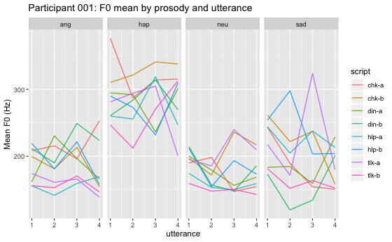

```r
f0_001_df <- extract_matlab_acoustics_dat_2(fn = paste0(acoustics_dir, "/001/data/F0/F0/mean/F0.mat"), "F0_mean")

f0_001_df %>%
  ggplot(.) +
  aes(utterance, F0_mean, color = script) +
  geom_line() +
  facet_grid(. ~ prosody) +
  ylab("Mean F0 (Hz)") +
  ggtitle("Participant 001: F0 mean by prosody and utterance")
```

## 4.4 Parse `script` into `script` and `order` variables

The ratings data have separate `script` and `order` variables.

```r
f0_001_df %>%
  tidyr::separate(., script, into = c("script", "order"))
```

| script | order | prosody | utterance | F0_mean |
| --- | --- | --- | --- | --- |
| chk | a | ang | 1 | 208.1734 |
| chk | a | ang | 2 | 215.4559 |
| chk | a | ang | 3 | 195.9910 |
| chk | a | ang | 4 | 253.0072 |
| chk | a | hap | 1 | 376.2629 |
| chk | a | hap | 2 | 287.2466 |
| chk | a | hap | 3 | 314.0293 |
| chk | a | hap | 4 | 315.4946 |
| chk | a | neu | 1 | 189.8569 |
| chk | a | neu | 2 | 198.1366 |

[output cut: 118 more lines]

## 4.5 Import and test functions from `R/gather_clean_acoustics.R`

```r
source("R/gather_clean_acoustics.R")
```

Now run `test_gather_clean_acoustics()` with the default parameters (`fam_id` == “001” and the “F0_mean” variable).

```r
test_gather_clean_acoustics()
```

```
Data extracted from '~/Box Sync/b-peep-project Shared/PEEP2 acoustics/001/data/F0/F0/MEAN/F0.mat'
```

| script | order | prosody | utterance | F0_mean |
| --- | --- | --- | --- | --- |
| chk | a | ang | 1 | 208.1734 |
| chk | a | ang | 2 | 215.4559 |
| chk | a | ang | 3 | 195.9910 |
| chk | a | ang | 4 | 253.0072 |
| chk | a | hap | 1 | 376.2629 |
| chk | a | hap | 2 | 287.2466 |
| chk | a | hap | 3 | 314.0293 |
| chk | a | hap | 4 | 315.4946 |
| chk | a | neu | 1 | 189.8569 |
| chk | a | neu | 2 | 198.1366 |

[output cut: 118 more lines]

Try it with the `HNR_mean` and a different participant.

```r
test_gather_clean_acoustics(this_fam = "002", this_measure_nm = "HNR_mean")
```

```
Data extracted from '~/Box Sync/b-peep-project Shared/PEEP2 acoustics/002/data/HNR/HNR/MEAN/HNR.mat'
```

| script | order | prosody | utterance | HNR_mean |
| --- | --- | --- | --- | --- |
| chk | a | ang | 1 | -33.3622554 |
| chk | a | ang | 2 | -53.5325615 |
| chk | a | ang | 3 | 3.7101298 |
| chk | a | ang | 4 | -4.1783800 |
| chk | a | hap | 1 | -25.0236472 |
| chk | a | hap | 2 | -39.7889039 |
| chk | a | hap | 3 | -10.1283701 |
| chk | a | hap | 4 | 10.5083614 |
| chk | a | neu | 1 | -28.6317187 |
| chk | a | neu | 2 | -68.8745973 |

[output cut: 118 more lines]

# 5 Next steps

1. Parse the `script` variable into separate `script` and `order` variables analogous to the ratings data.
   - 2019-08-01: Completed.
2. Create functions to recursively scour the acoustics data structure and generate files for each measure for each participant.
   - 2019-08-01: Partially done, see `R/gather_clean_acoustics.R`.
3. Save the files for each participant with a sensible naming scheme like `001_F0_mean.csv` or `001_HNR.csv`.
4. Create combined files across participants by measure.
5. Create summary (mean value across utterances) data for each recording as this is the data in the JECP paper. Focus on the `F0_mean`, standard deviation of F0, and speech rate variables. Confirm with Peter how to calculate standard deviation of F0 (by file/recording SD?), and speech rate.